COMBINED REPORT

# OncoProfiling Multi-Agent Analysis

Self-contained research report · generated 2026-08-13 13:26:33 EDT

## Run summary

| Agent | Status | Rows | Plot |
| --- | --- | --- | --- |
| **GO** | Completed | 588 | Available |

PROVENANCE

## Input and run identity

[output not shown]

### Analysis configuration

| Gene group | Not recorded |
| --- | --- |
| Protein-coding only | Not recorded |
| Adjusted p/FDR cutoff | Not recorded |
| Absolute effect cutoff | Not recorded |
| Maximum genes | Not recorded |

IDENTIFIER QUALITY

## Gene mapping summary

Identifier mapping was not required or was not recorded for this workflow.

INTERPRETATION STATE

## Observed results and local AI

| State | Biological interpretation generated locally with llama3.1:8b |
| --- | --- |
| Source | ollama |
| Model | llama3.1:8b |
| JSON contract | 4.0-ian-integrated-narrative |

Observed-result bullets are computed deterministically from saved result tables. Local AI text is an interpretive layer and cannot change those observations.

IAN-STYLE INTEGRATED REVIEW

## Gene Ontology (GO) Enrichment Analysis of Biological Processes Related to Wound Healing

Biological interpretation generated locally with llama3.1:8b

### Executive interpretation

This integrated narrative provides a comprehensive overview of the Gene Ontology (GO) enrichment analysis and its implications for understanding biological processes related to wound healing and tissue repair.

### Integrated biological model

The GO enrichment analysis reveals a significant over-representation of biological processes related to wound healing, epithelial cell proliferation, and chemotaxis. The top enriched terms include response to wounding, wound healing, epithelial cell proliferation, regulation of epithelial cell proliferation, chemotaxis, and cell chemotaxis. These findings suggest that the analyzed samples exhibit a coordinated response to wounding and tissue repair.

### Deep local narrative

#### Integrated Biological Interpretation

The enrichment analysis highlights the importance of epithelial cell proliferation in wound healing, with a RichFactor of 0.1713 and FoldEnrichment of 2.5322. The regulation of epithelial cell proliferation is also significantly enriched, indicating that this process is crucial for tissue repair. Chemotaxis, which involves the movement of cells towards chemical signals, is another key process involved in wound healing.

#### Result-Grounded Research Hypotheses

1. Do the enriched GO terms reflect a specific cellular response to wounding or a more general tissue repair mechanism?

This hypothesis can be tested by validating the observed enrichment using independent datasets or orthogonal assays.

This hypothesis can be determined by investigating the influence of experimental biases or sample characteristics on the observed enrichment.

#### Validation and Next Analyses

1. Validate the observed enrichment using independent datasets or orthogonal assays.

2. Investigate the relationship between the enriched GO terms and other biological processes or pathways.

3. Determine whether the observed enrichment is specific to wound healing or a more general tissue repair mechanism.

#### Interpretive Boundaries

The analysis is limited by the availability of annotated datasets and the specificity of the GO terms used in the enrichment analysis. The results may not generalize to other types of wounds or tissue injuries, and the observed enrichment of GO terms may be influenced by experimental biases or sample characteristics.

### Convergent signals

- None

### Candidate regulatory network

No regulatory network information is available for this agent.

### Hub candidates

- No STRING network result was supplied for hub prioritization.

### Novelty and literature context

Novelty and literature similarity cannot be verified without additional information.

### Recommended next analyses

1. Validate the observed enrichment using independent datasets or orthogonal assays.
2. Investigate the relationship between the enriched GO terms and other biological processes or pathways.
3. Determine whether the observed enrichment is specific to wound healing or a more general tissue repair mechanism.

### Interpretation limits

- The analysis is limited by the availability of annotated datasets and the specificity of the GO terms used in the enrichment analysis.
- The results may not generalize to other types of wounds or tissue injuries.
- The observed enrichment of GO terms may be influenced by experimental biases or sample characteristics.

BIOMARKER DISCOVERY

## Biomarker evidence and interpretation

Each agent shows deterministic observed results before any interpretive context.

Gene list

### GO Analysis

588 rows

Enriched Gene Ontology biological-process terms.

#### Interactive result profile

**Original analysis figure**

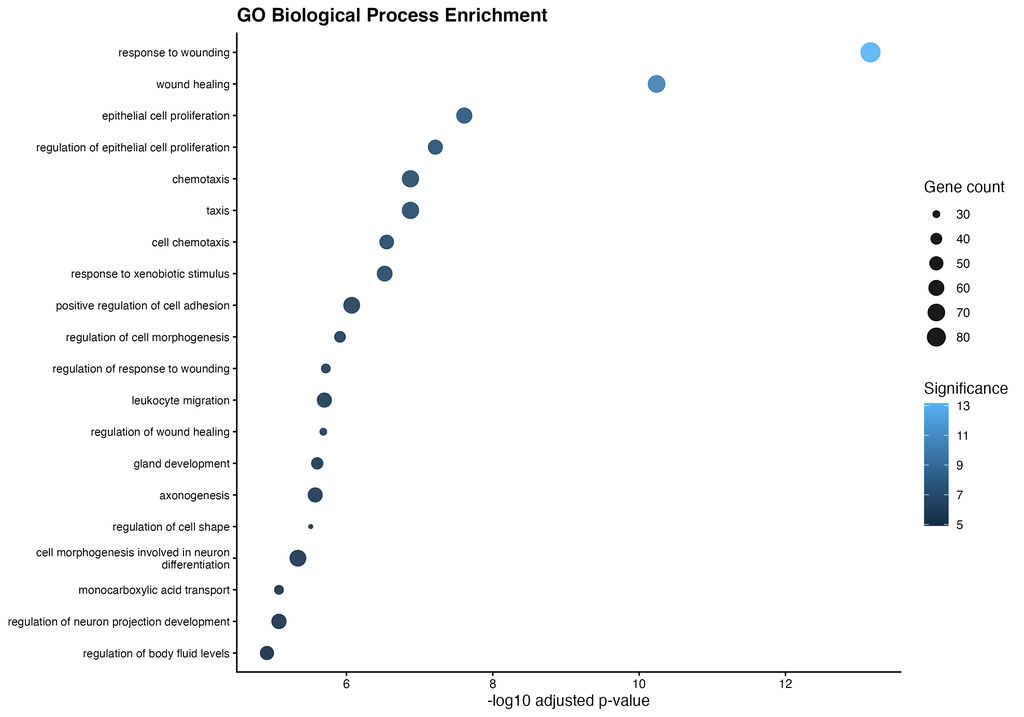

GO source visualization retained for reproducibility

#### Full-precision result preview

| ID | Description | GeneRatio | BgRatio | RichFactor | FoldEnrichment | zScore | pvalue | p.adjust | qvalue | geneID | Count |
| --- | --- | --- | --- | --- | --- | --- | --- | --- | --- | --- | --- |
| GO:0009611 | response to wounding | 89/1275 | 496/18842 | 0.18 | 2.65 | 10.04 | 1.37e-17 | 6.88e-14 | 5.01e-14 | ANXA5/TPM1/DCBLD2/LCK/ITGB5/HSPB1/RIPOR1/P2RY1/ZFP36L2/MYOF/…… | 89.00 |
| GO:0042060 | wound healing | 71/1275 | 394/18842 | 0.18 | 2.66 | 8.99 | 2.31e-14 | 5.77e-11 | 4.20e-11 | ANXA5/TPM1/DCBLD2/LCK/ITGB5/HSPB1/P2RY1/MYOF/CD109/TNFRSF12A…… | 71.00 |
| GO:0050673 | epithelial cell proliferation | 61/1275 | 356/18842 | 0.17 | 2.53 | 7.86 | 1.47e-11 | 2.45e-08 | 1.79e-08 | TRAF3IP2/VDR/EGFR/ZNF703/LOXL2/NUPR1/CCR3/SCN5A/AKT3/CYBA/ER…… | 61.00 |
| GO:0050678 | regulation of epithelial cell proliferation | 55/1275 | 312/18842 | 0.18 | 2.61 | 7.70 | 4.87e-11 | 6.10e-08 | 4.44e-08 | TRAF3IP2/VDR/EGFR/ZNF703/NUPR1/CCR3/SCN5A/AKT3/CYBA/EREG/ROB…… | 55.00 |
| GO:0006935 | chemotaxis | 68/1275 | 443/18842 | 0.15 | 2.27 | 7.28 | 1.60e-10 | 1.33e-07 | 9.71e-08 | ARHGEF16/GPNMB/TNFRSF11A/HSPB1/ROBO3/CXCL2/CCR3/S100A9/PDE4B…… | 68.00 |
| GO:0042330 | taxis | 68/1275 | 443/18842 | 0.15 | 2.27 | 7.28 | 1.60e-10 | 1.33e-07 | 9.71e-08 | ARHGEF16/GPNMB/TNFRSF11A/HSPB1/ROBO3/CXCL2/CCR3/S100A9/PDE4B…… | 68.00 |
| GO:0060326 | cell chemotaxis | 53/1275 | 311/18842 | 0.17 | 2.52 | 7.27 | 3.94e-10 | 2.82e-07 | 2.05e-07 | ARHGEF16/TNFRSF11A/HSPB1/CXCL2/CCR3/S100A9/PDE4B/PF4/AGR2/LG…… | 53.00 |
| GO:0009410 | response to xenobiotic stimulus | 59/1275 | 368/18842 | 0.16 | 2.37 | 7.15 | 4.80e-10 | 3.01e-07 | 2.19e-07 | UCHL1/TRAF3IP2/CYP2J2/COL1A1/LCK/ADD3/CSAG3/FOS/FBP1/FYN/PDE…… | 59.00 |
| GO:0045785 | positive regulation of cell adhesion | 65/1275 | 437/18842 | 0.15 | 2.20 | 6.83 | 1.53e-09 | 8.48e-07 | 6.17e-07 | TPM1/CIB1/LCK/GLI3/FYN/SHH/AGR2/NRG1/EPB41L4B/SKAP1/ETS1/FOX…… | 65.00 |
| GO:0022604 | regulation of cell morphogenesis | 40/1275 | 211/18842 | 0.19 | 2.80 | 7.09 | 2.45e-09 | 1.23e-06 | 8.93e-07 | OBSL1/TPM1/PLXND1/BAMBI/P2RY1/FYN/BAIAP2/FMNL1/CLDN4/SLC23A2…… | 40.00 |
| GO:1903034 | regulation of response to wounding | 34/1275 | 165/18842 | 0.21 | 3.05 | 7.11 | 4.21e-09 | 1.92e-06 | 1.39e-06 | CD109/TNFRSF12A/PF4/PHLDB2/CLDN4/CD36/CEACAM1/EPHB2/FERMT2/P…… | 34.00 |
| GO:0050900 | leukocyte migration | 55/1275 | 352/18842 | 0.16 | 2.31 | 6.68 | 4.81e-09 | 2.01e-06 | 1.46e-06 | TNFRSF11A/LCK/FYN/S100A9/GDF15/PDE4B/PF4/ICAM1/LGALS3/GPR35/…… | 55.00 |
| GO:0061041 | regulation of wound healing | 30/1275 | 135/18842 | 0.22 | 3.28 | 7.17 | 5.39e-09 | 2.07e-06 | 1.51e-06 | CD109/TNFRSF12A/PF4/PHLDB2/CLDN4/CD36/CEACAM1/EPHB2/FERMT2/APOE/CLDN1/TSPAN8/FOXA2/PLAUR/SERPINE1/MYLK/F2R/PLAT/CADM4/CLDN3/VIL1/FERMT1/ST3GAL4/DSC2/PDGFB/SLC12A2/CAV1/EMILIN2/ANXA1/SMOC2 | 30.00 |
| GO:0048732 | gland development | 42/1275 | 236/18842 | 0.18 | 2.63 | 6.79 | 7.03e-09 | 2.51e-06 | 1.83e-06 | HNF1B/ZNF703/SHH/NRG1/PKD2/PCSK9/HNF1A/ROBO1/CRIP1/GLI2/ALDH…… | 42.00 |
| GO:0007409 | axonogenesis | 55/1275 | 357/18842 | 0.15 | 2.28 | 6.56 | 8.02e-09 | 2.67e-06 | 1.95e-06 | PLXND1/EFNB3/DCLK1/ROBO3/APBB1/AUTS2/FYN/SHH/TENM3/SMO/BAIAP…… | 55.00 |
| GO:0008360 | regulation of cell shape | 28/1275 | 123/18842 | 0.23 | 3.36 | 7.09 | 9.84e-09 | 3.08e-06 | 2.24e-06 | TPM1/PLXND1/BAMBI/P2RY1/FYN/BAIAP2/FMNL1/MYH10/FERMT2/CCL24/FGD1/RHOU/LPAR1/EPS8/MSN/PALM2AKAP2/CCL2/PLXNB3/VIL1/FN1/MYH14/CDC42EP3/FBLIM1/CDC42EP5/VEGFA/RDX/ANXA1/RAC3 | 28.00 |
| GO:0048667 | cell morphogenesis involved in neuron differentiation | 65/1275 | 463/18842 | 0.14 | 2.07 | 6.31 | 1.57e-08 | 4.61e-06 | 3.36e-06 | OBSL1/PLXND1/EFNB3/TANC2/DCLK1/ROBO3/APBB1/AUTS2/FYN/SHH/NGE…… | 65.00 |
| GO:0015718 | monocarboxylic acid transport | 34/1275 | 178/18842 | 0.19 | 2.82 | 6.58 | 3.13e-08 | 8.37e-06 | 6.10e-06 | CRABP2/FABP1/MPC2/TNFRSF11A/SLC2A1/ATP8B1/SLC27A2/STARD5/SLC…… | 34.00 |
| GO:0010975 | regulation of neuron projection development | 56/1275 | 381/18842 | 0.15 | 2.17 | 6.23 | 3.18e-08 | 8.37e-06 | 6.10e-06 | OBSL1/PLXND1/EFNB3/CIB1/TANC2/ROBO3/APBB1/S100A9/NGEF/TENM3/…… | 56.00 |
| GO:0050878 | regulation of body fluid levels | 50/1275 | 327/18842 | 0.15 | 2.26 | 6.19 | 4.88e-08 | 1.22e-05 | 8.90e-06 | ANXA5/TRAF3IP2/MUC2/LCK/CFTR/HSPB1/P2RY1/PF4/ADRA2C/AGR2/UBA…… | 50.00 |
| GO:0015711 | organic anion transport | 61/1275 | 440/18842 | 0.14 | 2.05 | 6.00 | 6.88e-08 | 1.64e-05 | 1.19e-05 | SLC4A3/CRABP2/FABP1/SLC2A3/MGST1/MPC2/TNFRSF11A/SLC2A14/CFTR…… | 61.00 |
| GO:0007411 | axon guidance | 34/1275 | 185/18842 | 0.18 | 2.72 | 6.32 | 8.40e-08 | 1.91e-05 | 1.39e-05 | EFNB3/ROBO3/FYN/SHH/TENM3/SMO/ROBO1/SEMA6B/KALRN/PTPRM/PTPRO/SEMA7A/GLI2/ARHGEF25/TUBB3/NRP1/EPHB2/SEMA4G/WNT5A/WNT7B/EFNB1/SEMA4B/EPHB3/L1CAM/UNC5B/TUBB2B/SCN1B/PTK7/NELL2/BDNF/VEGFA/CHN1/NRP2/RAC3 | 34.00 |
| GO:0001935 | endothelial cell proliferation | 34/1275 | 186/18842 | 0.18 | 2.70 | 6.28 | 9.62e-08 | 1.93e-05 | 1.41e-05 | LOXL2/CCR3/AKT3/CYBA/NRARP/PTPRM/DLL4/NRP1/CCL24/WNT5A/MDK/APOE/PPARG/PIK3CD/GATA2/NR2F2/IL10/CCL2/PLXNB3/PLCG1/FGFR1/SPARC/EGFL7/FGFBP1/NGFR/RGCC/PDGFB/ANG/LRG1/STAT5A/CAV2/VEGFA/CAV1/NRP2 | 34.00 |
| GO:0097485 | neuron projection guidance | 34/1275 | 186/18842 | 0.18 | 2.70 | 6.28 | 9.62e-08 | 1.93e-05 | 1.41e-05 | EFNB3/ROBO3/FYN/SHH/TENM3/SMO/ROBO1/SEMA6B/KALRN/PTPRM/PTPRO/SEMA7A/GLI2/ARHGEF25/TUBB3/NRP1/EPHB2/SEMA4G/WNT5A/WNT7B/EFNB1/SEMA4B/EPHB3/L1CAM/UNC5B/TUBB2B/SCN1B/PTK7/NELL2/BDNF/VEGFA/CHN1/NRP2/RAC3 | 34.00 |
| GO:0001936 | regulation of endothelial cell proliferation | 32/1275 | 169/18842 | 0.19 | 2.80 | 6.33 | 9.78e-08 | 1.93e-05 | 1.41e-05 | CCR3/AKT3/CYBA/PTPRM/DLL4/NRP1/CCL24/WNT5A/MDK/APOE/PPARG/PIK3CD/GATA2/NR2F2/IL10/CCL2/PLXNB3/PLCG1/FGFR1/SPARC/EGFL7/FGFBP1/NGFR/RGCC/PDGFB/ANG/LRG1/STAT5A/CAV2/VEGFA/CAV1/NRP2 | 32.00 |

Previewing 25 of 588 rows. The complete full-precision CSV is in the results bundle.

#### Observed results · deterministic

- response to wounding: RichFactor=0.1794, FoldEnrichment=2.652, zScore=10.04, pvalue=0.00000000000000001374, p.adjust=0.00000000000006878, qvalue=0.00000000000005007
- wound healing: RichFactor=0.1802, FoldEnrichment=2.663, zScore=8.987, pvalue=0.00000000000002306, p.adjust=0.00000000005769, qvalue=0.00000000004199
- epithelial cell proliferation: RichFactor=0.1713, FoldEnrichment=2.532, zScore=7.863, pvalue=0.00000000001471, p.adjust=0.00000002454, qvalue=0.00000001786

#### Integrated biological interpretation

The Gene Ontology (GO) enrichment analysis reveals a significant over-representation of biological processes related to wound healing, epithelial cell proliferation, and chemotaxis. The top enriched terms include response to wounding, wound healing, epithelial cell proliferation, regulation of epithelial cell proliferation, chemotaxis, and cell chemotaxis. These findings suggest that the analyzed samples exhibit a coordinated response to wounding and tissue repair.

##### Key findings

- response to wounding (RichFactor: 0.1794, FoldEnrichment: 2.6517)
- wound healing (RichFactor: 0.1802, FoldEnrichment: 2.663)
- epithelial cell proliferation (RichFactor: 0.1713, FoldEnrichment: 2.5322)

##### Result-grounded research hypotheses

- Do the enriched GO terms reflect a specific cellular response to wounding or a more general tissue repair mechanism?
- Are there any correlations between the enriched GO terms and other biological processes or pathways?
- Can the observed enrichment of GO terms be attributed to specific experimental conditions or sample characteristics?

##### Recommended validation priorities

1. Validate the observed enrichment of GO terms using independent datasets or orthogonal assays.
2. Investigate the relationship between the enriched GO terms and other biological processes or pathways.
3. Determine whether the observed enrichment is specific to wound healing or a more general tissue repair mechanism.

##### Cancer relevance

Cannot be determined from the supplied result data alone.

##### Limitations

- The analysis is limited by the availability of annotated datasets and the specificity of the GO terms used in the enrichment analysis.
- The results may not generalize to other types of wounds or tissue injuries.
- The observed enrichment of GO terms may be influenced by experimental biases or sample characteristics.

METHODS AND VERSIONS

## Reproducible environment

**Interpretation method.** The local prompt adapts Dr. Tyc's IAN combined-review sequence: individual-agent review, pathway integration, groundedness checking, regulator/network assessment, hypothesis generation, validation planning, and high-level synthesis. Literature similarity and novelty are not asserted without a dedicated literature review.

Human identifier mapping uses the installed org.Hs.eg.db annotation. Agent-specific tests and thresholds are recorded in saved outputs and configuration above. Interactive bar charts prioritize precise comparison; 3D views are exploratory projections of three recorded metrics.

| component | version |
| --- | --- |
| R | 4.6.1 |
| shiny | 1.14.0 |
| clusterProfiler | 4.20.0 |
| org.Hs.eg.db | 3.23.1 |
| ReactomePA | 1.56.0 |
| STRINGdb | 2.24.0 |
| msigdbr | 26.1.0 |
| GSVA | 2.6.2 |
| immunedeconv | 2.1.4 |
| ggplot2 | 4.0.3 |
| plotly | 4.12.0 |
| htmlwidgets | 1.6.4 |
| jsonlite | 2.0.0 |
| httr2 | 1.3.0 |

LIMITATIONS

ARTIFACT MANIFEST

## Files represented in this report

| agent | artifact | file | exists | size_bytes | md5 | rows |
| --- | --- | --- | --- | --- | --- | --- |
| go | csv | go_results.csv | TRUE | 190,495.00 | 7a2700bbb36a680fc587384b0b468afb | 588.00 |
| go | plot | go_biological_process_dotplot.png | TRUE | 227,866.00 | d178ca27e110d9d2967e62368b585f98 |  |